# Kaggle Ecommerce Customers

## Kaggle-Ecommerce Customers

```python
import pandas as pd
import numpy as np
import matplotlib.pyplot as plt
import seaborn as sns
%matplotlib inline
```

```python
data=pd.read_csv("Ecommerce.csv")
```

```python
data.head()
```

|  | Email | Address | Avatar | Avg. Session Length | Time on App | Time on Website | Length of Membership | Yearly Amount Spent |
| --- | --- | --- | --- | --- | --- | --- | --- | --- |
| 0 | mstephenson@fernandez.com | 835 Frank Tunnel\nWrightmouth, MI 82180-9605 | Violet | 34.497268 | 12.655651 | 39.577668 | 4.082621 | 587.951054 |
| 1 | hduke@hotmail.com | 4547 Archer Common\nDiazchester, CA 06566-8576 | DarkGreen | 31.926272 | 11.109461 | 37.268959 | 2.664034 | 392.204933 |
| 2 | pallen@yahoo.com | 24645 Valerie Unions Suite 582\nCobbborough, D... | Bisque | 33.000915 | 11.330278 | 37.110597 | 4.104543 | 487.547505 |
| 3 | riverarebecca@gmail.com | 1414 David Throughway\nPort Jason, OH 22070-1220 | SaddleBrown | 34.305557 | 13.717514 | 36.721283 | 3.120179 | 581.852344 |
| 4 | mstephens@davidson-herman.com | 14023 Rodriguez Passage\nPort Jacobville, PR 3... | MediumAquaMarine | 33.330673 | 12.795189 | 37.536653 | 4.446308 | 599.406092 |

```python
data.shape
```

```
(500, 8)
```

```python
data.info()
```

```
<class 'pandas.core.frame.DataFrame'>
RangeIndex: 500 entries, 0 to 499
Data columns (total 8 columns):
Email                   500 non-null object
Address                 500 non-null object
Avatar                  500 non-null object
Avg. Session Length     500 non-null float64
Time on App             500 non-null float64
Time on Website         500 non-null float64
Length of Membership    500 non-null float64
Yearly Amount Spent     500 non-null float64
dtypes: float64(5), object(3)
memory usage: 31.3+ KB
```

```python
#Categorical Variables
cat=data.select_dtypes(include ='object')
cat.head()
```

|  | Email | Address | Avatar |
| --- | --- | --- | --- |
| 0 | mstephenson@fernandez.com | 835 Frank Tunnel\nWrightmouth, MI 82180-9605 | Violet |
| 1 | hduke@hotmail.com | 4547 Archer Common\nDiazchester, CA 06566-8576 | DarkGreen |
| 2 | pallen@yahoo.com | 24645 Valerie Unions Suite 582\nCobbborough, D... | Bisque |
| 3 | riverarebecca@gmail.com | 1414 David Throughway\nPort Jason, OH 22070-1220 | SaddleBrown |
| 4 | mstephens@davidson-herman.com | 14023 Rodriguez Passage\nPort Jacobville, PR 3... | MediumAquaMarine |

```python
cat['Email'].nunique(),cat['Address'].nunique(),cat['Avatar'].nunique()
```

```
(500, 500, 138)
```

```
SlateBlue               7
GreenYellow             7
CadetBlue               7
Cyan                    7
Teal                    7
OliveDrab               6
Bisque                  6
DarkSeaGreen            6
DarkViolet              6
Moccasin                6
DarkGoldenRod           6
PeachPuff               6
Wheat                   6
LightSkyBlue            6
Tomato                  6
Purple                  6
Aqua                    6
Orange                  6
Turquoise               6
SaddleBrown             6
BlueViolet              6
DeepPink                6
BlanchedAlmond          5
LightGreen              5
Olive                   5
MediumSpringGreen       5
Orchid                  5
Thistle                 5
SteelBlue               5
LimeGreen               5
                       ..
DarkGray                2
LightYellow             2
IndianRed               2
OrangeRed               2
FireBrick               2
DarkSlateGray           2
Khaki                   2
AliceBlue               2
MediumOrchid            2
Chartreuse              2
GoldenRod               2
Silver                  2
Fuchsia                 2
Snow                    2
PaleGreen               1
Yellow                  1
PowderBlue              1
MediumPurple            1
LawnGreen               1
DeepSkyBlue             1
PaleTurquoise           1
LightGoldenRodYellow    1
Coral                   1
PaleGoldenRod           1
PapayaWhip              1
CornflowerBlue          1
LightSlateGray          1
Azure                   1
NavajoWhite             1
Red                     1
Name: Avatar, Length: 138, dtype: int64
```

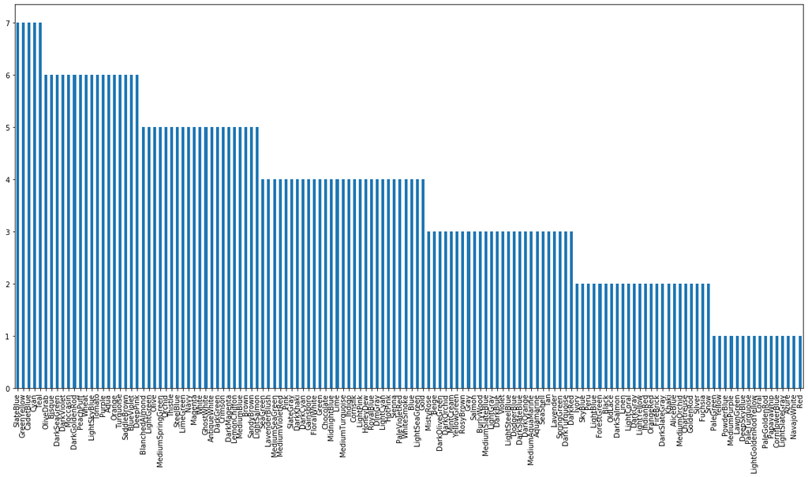

```python
av=cat['Avatar'].value_counts()
print(av)
av.plot.bar(figsize=(20,10))
```

```python
#Numerical variables
num=data.select_dtypes(exclude ='object')
num.head()
```

|  | Avg. Session Length | Time on App | Time on Website | Length of Membership | Yearly Amount Spent |
| --- | --- | --- | --- | --- | --- |
| 0 | 34.497268 | 12.655651 | 39.577668 | 4.082621 | 587.951054 |
| 1 | 31.926272 | 11.109461 | 37.268959 | 2.664034 | 392.204933 |
| 2 | 33.000915 | 11.330278 | 37.110597 | 4.104543 | 487.547505 |
| 3 | 34.305557 | 13.717514 | 36.721283 | 3.120179 | 581.852344 |
| 4 | 33.330673 | 12.795189 | 37.536653 | 4.446308 | 599.406092 |

```python
num.describe().T
```

|  | count | mean | std | min | 25% | 50% | 75% | max |
| --- | --- | --- | --- | --- | --- | --- | --- | --- |
| Avg. Session Length | 500.0 | 33.053194 | 0.992563 | 29.532429 | 32.341822 | 33.082008 | 33.711985 | 36.139662 |
| Time on App | 500.0 | 12.052488 | 0.994216 | 8.508152 | 11.388153 | 11.983231 | 12.753850 | 15.126994 |
| Time on Website | 500.0 | 37.060445 | 1.010489 | 33.913847 | 36.349257 | 37.069367 | 37.716432 | 40.005182 |
| Length of Membership | 500.0 | 3.533462 | 0.999278 | 0.269901 | 2.930450 | 3.533975 | 4.126502 | 6.922689 |
| Yearly Amount Spent | 500.0 | 499.314038 | 79.314782 | 256.670582 | 445.038277 | 498.887875 | 549.313828 | 765.518462 |

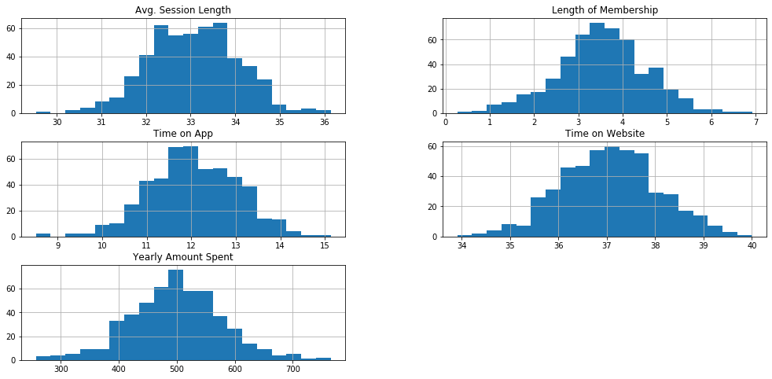

```python
data.hist(figsize=(17,8),bins=20);
```

### Observation :

#### 1. Customer majorly spend Avg session length time in range 32-34 minutes.

#### 2. Most of customer have Length of Membership between 3-4 years.

#### 3. Time spend on app has on average was 11.5 to 12 minutes.

#### 4. Time spend on website was on average of approximate 37 mins.

#### 5. Customer yearly amount spent on average of approximately 500.

## Is there any difference for Time spent on App vs Web ?

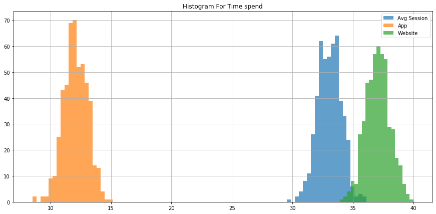

```python
plt.figure(figsize=(15,7))
data['Avg. Session Length'].hist(bins=20, label='Avg Session', alpha=0.7)
data['Time on App'].hist(bins=20, label='App',alpha=0.7)
data['Time on Website'].hist(bins=20, label='Website', alpha=0.7)
plt.title("Histogram For Time spend")
plt.legend();
```

### Observation:

#### 1. Surprisingly customer spent most of time on website when compared to app.

## Does my data has any outlier or skewness ?

```python
# Checking skewness if they are normally distributed
print("Skewness for Avg. Session Length",data['Avg. Session Length'].skew())
print("Skewness for Time on App",data['Time on App'].skew())
print("Skewness for Length of Membership",data['Length of Membership'].skew())
print("Skewness for Yearly Amount Spent",data['Yearly Amount Spent'].skew())
```

```
Skewness for Avg. Session Length -0.03217480705175736
Skewness for Time on App -0.0891210975109327
Skewness for Length of Membership -0.10660805308863916
Skewness for Yearly Amount Spent 0.034790184115234546
```

#### Slight skewness can be seen for variable length of membership. Rest seems to be quite normally distributed.

```python
data["Yearly Amount Spent"].describe()
```

```
count    500.000000
mean     499.314038
std       79.314782
min      256.670582
25%      445.038277
50%      498.887875
75%      549.313828
max      765.518462
Name: Yearly Amount Spent, dtype: float64
```

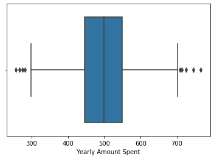

```python
sns.boxplot(data["Yearly Amount Spent"])
```

```python
#Outlier detection
Q1=data['Yearly Amount Spent'].quantile(0.25)
Q3=data['Yearly Amount Spent'].quantile(0.75)
IQR=Q3-Q1
print(Q1)
print(Q3)
print(IQR)
Lower_Whisker = Q1-1.5*IQR
Upper_Whisker = Q3+1.5*IQR
print("Outlier for Low",Lower_Whisker)
print("Outlier for Upper",Upper_Whisker)
```

```
445.0382770450168
549.313827581537
104.2755505365202
Outlier for Low 288.6249512402365
Outlier for Upper 705.7271533863172
```

### Which Avatar has highest average yearly amount spent ?

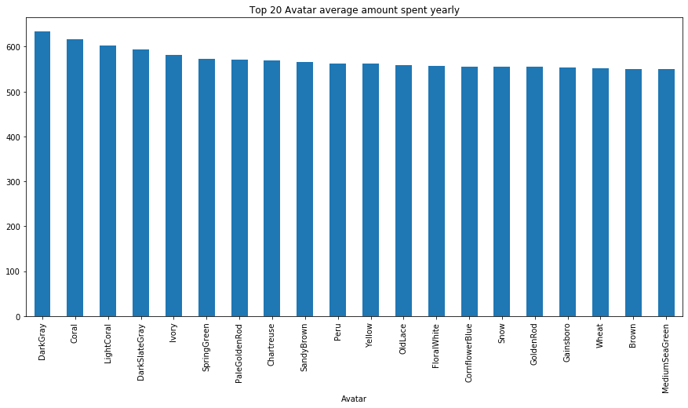

```python
avatar_spend_yly=data.groupby('Avatar')['Yearly Amount Spent'].mean().sort_values(ascending=False).head(20)
avatar_spend_yly.plot.bar(figsize=(15,7),title='Top 20 Avatar average amount spent yearly');
```

## Is there any relationship between features and target ?

```python
corr=num.corr()
```

```python
mask = np.zeros_like(data.corr())
triangle_indices = np.triu_indices_from(mask)
mask[triangle_indices] = True
mask
```

```
array([[1., 1., 1., 1., 1.],
       [0., 1., 1., 1., 1.],
       [0., 0., 1., 1., 1.],
       [0., 0., 0., 1., 1.],
       [0., 0., 0., 0., 1.]])
```

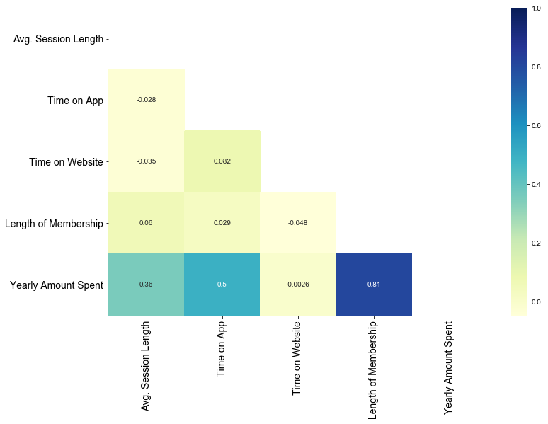

```python
plt.figure(figsize=(12,8))
sns.heatmap(corr,mask=mask,annot=True, cmap="YlGnBu")
sns.set_style('white')
plt.xticks(fontsize=14)
plt.yticks(fontsize=14)
plt.show()
```

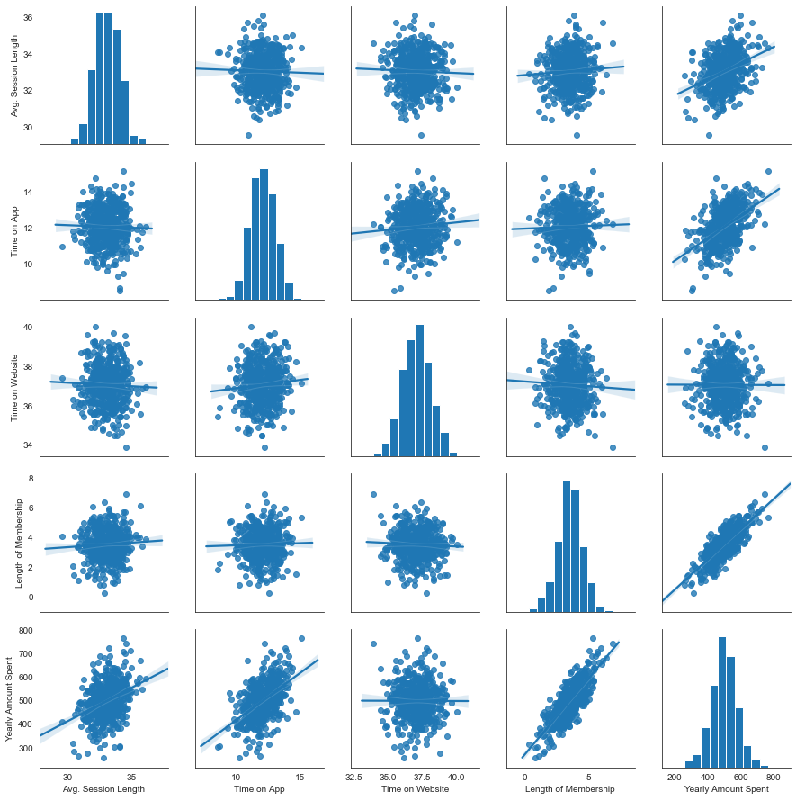

```python
sns.pairplot(num, kind='reg')
```

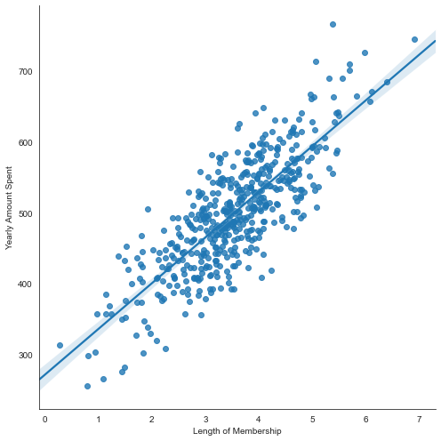

```python
sns.lmplot(x='Length of Membership', y='Yearly Amount Spent', data=data, size=7)
plt.show()
```

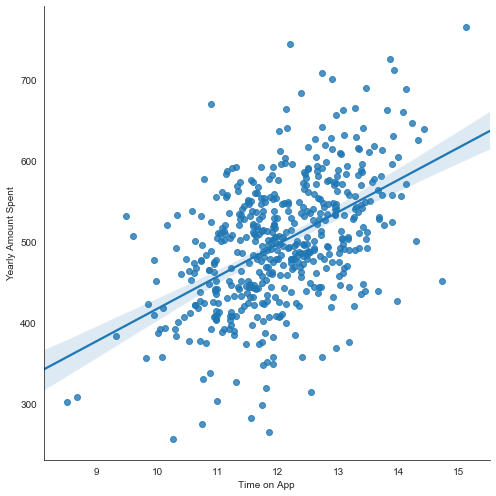

```python
sns.lmplot(x='Time on App', y='Yearly Amount Spent', data=data, size=7)
plt.show()
```

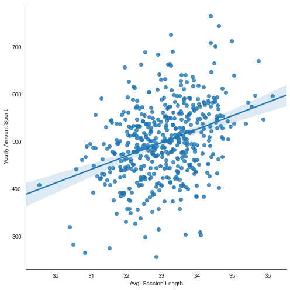

```python
sns.lmplot(x='Avg. Session Length', y='Yearly Amount Spent', data=data, size=7)
plt.show()
```

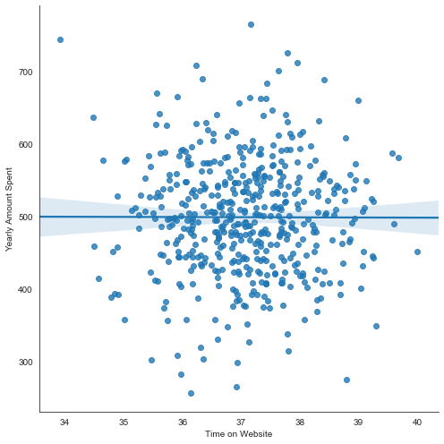

```python
sns.lmplot(x='Time on Website', y='Yearly Amount Spent', data=data, size=7)
plt.show()
```

### Observation:

#### 1. Strong positive relation can be seen between length of Membership and target variable.

#### 2. Unexpected time spent on website has slight negative relationship.

#### 3. Avg Session length and Time on App also have slight positive relationship.

## Base Model

```python
X=num.drop("Yearly Amount Spent", axis=1)
y=num["Yearly Amount Spent"]
```

```python
from sklearn.model_selection import train_test_split
X_train,X_test,y_train,y_test=train_test_split(X,y,test_size=0.3,random_state=0)
```

```python
X_train.shape,X_test.shape,y_train.shape,y_test.shape
```

```
((350, 4), (150, 4), (350,), (150,))
```

```python
from sklearn.linear_model import LinearRegression
lr_base=LinearRegression()
lr_base.fit(X_train,y_train)
```

```
LinearRegression(copy_X=True, fit_intercept=True, n_jobs=None, normalize=False)
```

```python
from sklearn.model_selection import cross_val_score
cvtrain=cross_val_score(lr_base,X_train,y_train, cv=10)
cvtest=cross_val_score(lr_base,X_test,y_test,cv=10)
print('Cross validation score train:', cvtrain)
print('Cross validation score test:', cvtest)
```

```
Cross validation score train: [0.97642322 0.98442797 0.98742151 0.98422442 0.98399495 0.9844517
 0.98087665 0.9795409  0.9868426  0.97936895]
Cross validation score test: [0.988563   0.98410119 0.98811733 0.97179967 0.98670335 0.98977636
 0.9861973  0.97506086 0.97937545 0.98787345]
```

```python
mcvtrain=np.mean(cvtrain)
mcvtest=np.mean(cvtest)
print('Mean Cross validation score train:', mcvtrain)
print('Mena Cross validation score test:', mcvtest)
```

```
Mean Cross validation score train: 0.9827572866846157
Mena Cross validation score test: 0.9837567963956971
```

```python
# r-squared for training and test datasets
print('Training data r-squared:', lr_base.score(X_train, y_train))
print('Test data r-squared:', lr_base.score(X_test, y_test))

print('Intercept', lr_base.intercept_)
pd.DataFrame(data=lr_base.coef_, index=X_train.columns,columns=['coef'])
```

```
Training data r-squared: 0.9839380279327443
Test data r-squared: 0.9849262667370623
Intercept -1037.8257485695394
```

|  | coef |
| --- | --- |
| Avg. Session Length | 25.767530 |
| Time on App | 38.800394 |
| Time on Website | -0.018041 |
| Length of Membership | 61.852568 |

```python
y_pred_base=lr_base.predict(X_test)
```

```python
base_pred=pd.DataFrame({'Actual':y_test,'Predicted':y_pred_base,'Residual':(y_test-y_pred_base)})
base_pred.head(10)
```

|  | Actual | Predicted | Residual |
| --- | --- | --- | --- |
| 90 | 449.070319 | 438.053618 | 11.016701 |
| 254 | 482.602467 | 489.885692 | -7.283225 |
| 283 | 374.269675 | 370.691035 | 3.578640 |
| 445 | 513.153112 | 514.760391 | -1.607279 |
| 461 | 502.771075 | 496.718922 | 6.052153 |
| 15 | 461.780742 | 451.552781 | 10.227961 |
| 316 | 466.421199 | 457.788676 | 8.632523 |
| 489 | 327.377953 | 336.679400 | -9.301447 |
| 159 | 528.223809 | 527.814740 | 0.409069 |
| 153 | 657.019924 | 663.594557 | -6.574633 |

```python
#Evaluating the Algorithm
from sklearn.metrics import mean_absolute_error, mean_squared_error,r2_score

print('Mean Absolute Error:',mean_absolute_error(y_test, y_pred_base))
print('Mean Absolute percent error',np.mean(np.abs((y_test - y_pred_base) / y_test)) * 100)
print('Mean Squared Error:',mean_squared_error(y_test, y_pred_base))
print('Root Mean Squared Error:', np.sqrt(mean_squared_error(y_test, y_pred_base)))
print('R2 score:',r2_score(y_test, y_pred_base))
```

```
Mean Absolute Error: 7.8513771708614435
Mean Absolute percent error 1.6346745202849091
Mean Squared Error: 94.55779479273288
Root Mean Squared Error: 9.724083236620967
R2 score: 0.9849262667370623
```

#### Overall 98% variance can be explained by base model.

### Are residual are randomly distributed ?

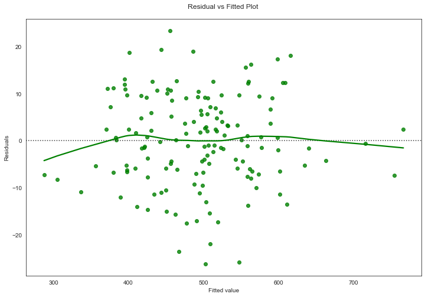

```python
plt.figure(figsize=(12,8))
ax = sns.residplot(base_pred['Predicted'],base_pred["Residual"], lowess = True, color = 'g')
ax.set(xlabel = 'Fitted value', ylabel = 'Residuals', title = 'Residual vs Fitted Plot \n')
plt.show()
```

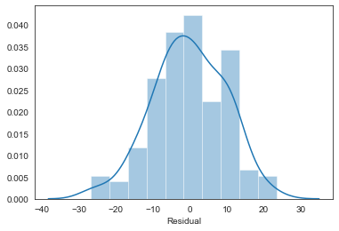

```python
sns.distplot(base_pred['Residual'])
```

```python
base_pred['Residual'].skew() # Negitively Skewed
```

```
-0.19565021907785837
```

### Feature importance by p-value

```python
import statsmodels.api as sm
X_const = sm.add_constant(X_train)

model = sm.OLS(y_train, X_const)
results = model.fit()

#results.params
#results.pvalues

pd.DataFrame({'coef': results.params, 'p-value': round(results.pvalues, 3)})
```

|  | coef | p-value |
| --- | --- | --- |
| const | -1037.825749 | 0.000 |
| Avg. Session Length | 25.767530 | 0.000 |
| Time on App | 38.800394 | 0.000 |
| Time on Website | -0.018041 | 0.973 |
| Length of Membership | 61.852568 | 0.000 |

#### Time on website with p value more than 0.05 and not significant. Hence can be drop out later for model selection.

```python
results.summary()
```

OLS Regression Results

| Dep. Variable: | Yearly Amount Spent | R-squared: | 0.984 |
| --- | --- | --- | --- |
| Model: | OLS | Adj. R-squared: | 0.984 |
| Method: | Least Squares | F-statistic: | 5284. |
| Date: | Fri, 21 Feb 2020 | Prob (F-statistic): | 5.40e-308 |
| Time: | 02:59:18 | Log-Likelihood: | -1303.6 |
| No. Observations: | 350 | AIC: | 2617. |
| Df Residuals: | 345 | BIC: | 2636. |
| Df Model: | 4 |  |  |
| Covariance Type: | nonrobust |  |  |

|  | coef | std err | t | P>\|t\| | [0.025 | 0.975] |
| --- | --- | --- | --- | --- | --- | --- |
| const | -1037.8257 | 29.051 | -35.725 | 0.000 | -1094.965 | -980.687 |
| Avg. Session Length | 25.7675 | 0.583 | 44.169 | 0.000 | 24.620 | 26.915 |
| Time on App | 38.8004 | 0.547 | 70.996 | 0.000 | 37.725 | 39.875 |
| Time on Website | -0.0180 | 0.528 | -0.034 | 0.973 | -1.057 | 1.021 |
| Length of Membership | 61.8526 | 0.548 | 112.882 | 0.000 | 60.775 | 62.930 |

| Omnibus: | 0.600 | Durbin-Watson: | 2.002 |
| --- | --- | --- | --- |
| Prob(Omnibus): | 0.741 | Jarque-Bera (JB): | 0.386 |
| Skew: | 0.040 | Prob(JB): | 0.824 |
| Kurtosis: | 3.142 | Cond. No. | 2.76e+03 |

Warnings:  
[1] Standard Errors assume that the covariance matrix of the errors is correctly specified.  
[2] The condition number is large, 2.76e+03. This might indicate that there are  
strong multicollinearity or other numerical problems.

#### No autocorrelation as Durbin-Watson score is 2.002

```python
from mlxtend.feature_selection import SequentialFeatureSelector as sfs

# Build step forward feature selection
feature_select= sfs(lr_base,k_features=4,forward=True,
           floating=False, scoring='r2',
           verbose=2,
           cv=5)

# Perform SFFS
sfs1 = feature_select.fit(X_train, y_train)
```

```
[Parallel(n_jobs=1)]: Using backend SequentialBackend with 1 concurrent workers.
[Parallel(n_jobs=1)]: Done   1 out of   1 | elapsed:    0.0s remaining:    0.0s
[Parallel(n_jobs=1)]: Done   4 out of   4 | elapsed:    0.0s finished

[2020-02-21 02:59:18] Features: 1/4 -- score: 0.6648223173094819[Parallel(n_jobs=1)]: Using backend SequentialBackend with 1 concurrent workers.
[Parallel(n_jobs=1)]: Done   1 out of   1 | elapsed:    0.0s remaining:    0.0s
[Parallel(n_jobs=1)]: Done   3 out of   3 | elapsed:    0.0s finished

[2020-02-21 02:59:18] Features: 2/4 -- score: 0.8885279359337759[Parallel(n_jobs=1)]: Using backend SequentialBackend with 1 concurrent workers.
[Parallel(n_jobs=1)]: Done   1 out of   1 | elapsed:    0.0s remaining:    0.0s
[Parallel(n_jobs=1)]: Done   2 out of   2 | elapsed:    0.0s finished

[2020-02-21 02:59:18] Features: 3/4 -- score: 0.9836363858503774[Parallel(n_jobs=1)]: Using backend SequentialBackend with 1 concurrent workers.
[Parallel(n_jobs=1)]: Done   1 out of   1 | elapsed:    0.0s remaining:    0.0s
[Parallel(n_jobs=1)]: Done   1 out of   1 | elapsed:    0.0s finished

[2020-02-21 02:59:18] Features: 4/4 -- score: 0.9836229187147805
```

```python
# Cant predicted but foward selection method as with 3  or 4 features giving same accuracy
```

```python
from sklearn.model_selection import RandomizedSearchCV
# Number of trees in random forest
n_estimators = [int(x) for x in np.linspace(start = 200, stop = 2000, num = 10)]
# Number of features to consider at every split
max_features = ['auto', 'sqrt']
# Maximum number of levels in tree
max_depth = [int(x) for x in np.linspace(10, 110, num = 11)]
max_depth.append(None)
# Minimum number of samples required to split a node
min_samples_split = [2, 5, 10]
# Minimum number of samples required at each leaf node
min_samples_leaf = [1, 2, 4]
# Method of selecting samples for training each tree
bootstrap = [True, False]
# Create the random grid
random_grid = {'n_estimators': n_estimators,
               'max_features': max_features,
               'max_depth': max_depth,
               'min_samples_split': min_samples_split,
               'min_samples_leaf': min_samples_leaf,
               'bootstrap': bootstrap}
print(random_grid)
```

```
{'n_estimators': [200, 400, 600, 800, 1000, 1200, 1400, 1600, 1800, 2000], 'max_features': ['auto', 'sqrt'], 'max_depth': [10, 20, 30, 40, 50, 60, 70, 80, 90, 100, 110, None], 'min_samples_split': [2, 5, 10], 'min_samples_leaf': [1, 2, 4], 'bootstrap': [True, False]}
```

```python
# Use the random grid to search for best hyperparameters
# First create the base model to tune
rf = RandomForestRegressor()
# Random search of parameters, using 3 fold cross validation,
# search across 10 different combinations, and use all available cores
rf_rs = RandomizedSearchCV(estimator = rf, param_distributions = random_grid, n_iter = 10, cv = 3, verbose=2, random_state=42, n_jobs = -1)
# Fit the random search model
rf_rs.fit(X_train,y_train)
```

```
Fitting 3 folds for each of 10 candidates, totalling 30 fits
```

```
[Parallel(n_jobs=-1)]: Using backend LokyBackend with 4 concurrent workers.
[Parallel(n_jobs=-1)]: Done  30 out of  30 | elapsed:   19.9s finished
```

```
RandomizedSearchCV(cv=3, error_score=nan,
                   estimator=RandomForestRegressor(bootstrap=True,
                                                   ccp_alpha=0.0,
                                                   criterion='mse',
                                                   max_depth=None,
                                                   max_features='auto',
                                                   max_leaf_nodes=None,
                                                   max_samples=None,
                                                   min_impurity_decrease=0.0,
                                                   min_impurity_split=None,
                                                   min_samples_leaf=1,
                                                   min_samples_split=2,
                                                   min_weight_fraction_leaf=0.0,
                                                   n_estimators=100,
                                                   n_jobs=None, oob_score=Fals...
                   param_distributions={'bootstrap': [True, False],
                                        'max_depth': [10, 20, 30, 40, 50, 60,
                                                      70, 80, 90, 100, 110,
                                                      None],
                                        'max_features': ['auto', 'sqrt'],
                                        'min_samples_leaf': [1, 2, 4],
                                        'min_samples_split': [2, 5, 10],
                                        'n_estimators': [200, 400, 600, 800,
                                                         1000, 1200, 1400, 1600,
                                                         1800, 2000]},
                   pre_dispatch='2*n_jobs', random_state=42, refit=True,
                   return_train_score=False, scoring=None, verbose=2)
```

```python
rf_rs.best_params_
```

```
{'n_estimators': 2000,
 'min_samples_split': 5,
 'min_samples_leaf': 2,
 'max_features': 'auto',
 'max_depth': 50,
 'bootstrap': True}
```

```python
rfr=RandomForestRegressor(n_estimators=2000,
 min_samples_split=5,
 min_samples_leaf=2,
 max_features='auto',
 max_depth=50,
 bootstrap=True)
```

```python
rfr.fit(X_train,y_train)
```

```
RandomForestRegressor(bootstrap=True, ccp_alpha=0.0, criterion='mse',
                      max_depth=50, max_features='auto', max_leaf_nodes=None,
                      max_samples=None, min_impurity_decrease=0.0,
                      min_impurity_split=None, min_samples_leaf=2,
                      min_samples_split=5, min_weight_fraction_leaf=0.0,
                      n_estimators=2000, n_jobs=None, oob_score=False,
                      random_state=None, verbose=0, warm_start=False)
```

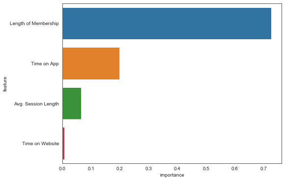

```python
# Dataframe
feature_rank=pd.DataFrame({'feature':X_train.columns,'importance':rfr.feature_importances_})
#Sorting
feature_rank=feature_rank.sort_values('importance',ascending=False)
#ploting
plt.figure(figsize=(8,6))
sns.barplot(y='feature',x='importance',data=feature_rank)
plt.title("Feature Selection on Feature Importance")
```

#### By randomforest 'Length of Membership', 'Time on App' and 'Avg.Session Length' are be important feature.Therefore dropping feature 'Time on Website' least important feature.

### Testing for Multicollinearity

```python
from statsmodels.stats.outliers_influence import variance_inflation_factor
variance_inflation_factor(exog=X_const.values, exog_idx=1)
```

```
1.0202950733314264
```

```python
vif = [variance_inflation_factor(exog=X_const.values,
                                 exog_idx=i) for i in range(X_const.shape[1])]

pd.DataFrame({'coef_name': X_const.columns,
             'vif': np.around(vif, 2)})
```

|  | coef_name | vif |
| --- | --- | --- |
| 0 | const | 2894.46 |
| 1 | Avg. Session Length | 1.02 |
| 2 | Time on App | 1.01 |
| 3 | Time on Website | 1.01 |
| 4 | Length of Membership | 1.01 |

```python
# No multicollinearity can be seen
```

```python
y_pred_o=results.predict(X_const)
residual=results.resid
```

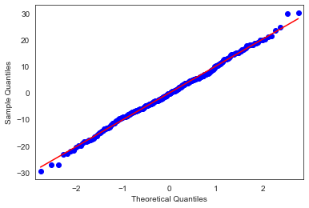

```python
# Checking for normality
fig=sm.qqplot(residual, line='r') # Normally distributed
```

```python
# Overall base model - Satisfy following assumptions for linear model
# No Multicollinearity
# No auto correlation
# Residual are normally distributed
```

```python
# Model with selected features
X1=num.drop(["Time on Website","Yearly Amount Spent"], axis=1)
y1=num["Yearly Amount Spent"]


X_train,X_test,y_train,y_test=train_test_split(X1,y1,test_size=0.3,random_state=0)
```

```python
from sklearn.linear_model import LinearRegression
lr_sf=LinearRegression()
lr_sf.fit(X_train,y_train)
```

```
LinearRegression(copy_X=True, fit_intercept=True, n_jobs=None, normalize=False)
```

```python
# r-squared for training and test datasets
print('Training data r-squared:', lr_sf.score(X_train, y_train))
print('Test data r-squared:', lr_sf.score(X_test, y_test))

print('Intercept', lr_sf.intercept_)
pd.DataFrame(data=lr_sf.coef_, index=X_train.columns,columns=['coef'])
```

```
Training data r-squared: 0.9839379735833186
Test data r-squared: 0.9849350144694914
Intercept -1038.5229533269173
```

|  | coef |
| --- | --- |
| Avg. Session Length | 25.768789 |
| Time on App | 38.799077 |
| Length of Membership | 61.853317 |

```python
y_pred_sf=lr_sf.predict(X_test)
```

```python
sf_pred=pd.DataFrame({'Actual':y_test,'Predicted':y_pred_sf,'Residual':(y_test-y_pred_sf)})
sf_pred.head(10)
```

|  | Actual | Predicted | Residual |
| --- | --- | --- | --- |
| 90 | 449.070319 | 438.065977 | 11.004342 |
| 254 | 482.602467 | 489.877578 | -7.275110 |
| 283 | 374.269675 | 370.665351 | 3.604323 |
| 445 | 513.153112 | 514.734405 | -1.581293 |
| 461 | 502.771075 | 496.687171 | 6.083904 |
| 15 | 461.780742 | 451.533479 | 10.247263 |
| 316 | 466.421199 | 457.792036 | 8.629163 |
| 489 | 327.377953 | 336.679099 | -9.301146 |
| 159 | 528.223809 | 527.839956 | 0.383854 |
| 153 | 657.019924 | 663.591956 | -6.572032 |

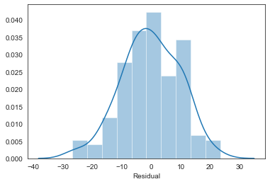

```python
sns.distplot(sf_pred["Residual"])
```

```python
sf_pred["Residual"].skew()
```

```
-0.19618919853371755
```

```python
#Evaluating the Algorithm
from sklearn.metrics import mean_absolute_error, mean_squared_error,r2_score

print('Mean Absolute Error:',mean_absolute_error(y_test, y_pred_sf))
print('Mean Absolute percent error',np.mean(np.abs((y_test - y_pred_sf) / y_test)) * 100)
print('Mean Squared Error:',mean_squared_error(y_test, y_pred_sf))
print('Root Mean Squared Error:', np.sqrt(mean_squared_error(y_test, y_pred_sf)))
print('R2 score:',r2_score(y_test, y_pred_sf))
```

```
Mean Absolute Error: 7.849601110072722
Mean Absolute percent error 1.634302473224059
Mean Squared Error: 94.50292011281763
Root Mean Squared Error: 9.721261240848207
R2 score: 0.9849350144694914
```

```python
score=pd.DataFrame({"model":['Base', "SF"],
              "Mean Absolute Error":[mean_absolute_error(y_test, y_pred_base),mean_absolute_error(y_test, y_pred_sf)],
             "Mean Absolute percent error":[np.mean(np.abs((y_test - y_pred_base) / y_test)) * 100,np.mean(np.abs((y_test - y_pred_sf) / y_test)) * 100],
             "Mean Squared Error":[mean_squared_error(y_test, y_pred_base),mean_squared_error(y_test, y_pred_sf)],
             "Root Mean Squared Error":[np.sqrt(mean_squared_error(y_test, y_pred_base)),np.sqrt(mean_squared_error(y_test, y_pred_sf))],
             "R2 score":[r2_score(y_test, y_pred_base),r2_score(y_test, y_pred_sf)]})
score
```

|  | model | Mean Absolute Error | Mean Absolute percent error | Mean Squared Error | Root Mean Squared Error | R2 score |
| --- | --- | --- | --- | --- | --- | --- |
| 0 | Base | 7.851377 | 1.634675 | 94.557795 | 9.724083 | 0.984926 |
| 1 | SF | 7.849601 | 1.634302 | 94.502920 | 9.721261 | 0.984935 |

```python
# No significant difference between base model and selected features model, almost same score.
```

```python
# Further improvement can be made by:
# Capping target outlier
# by scaling
# checking all assumption for linear regression
# Hyperparameter tunning
# Regularizing
```

## Building model with Rigde, Lasso and elastic

```python
# Rigde Regulariztion
from scipy.stats import uniform as sp_rand
from sklearn import datasets
from sklearn.linear_model import Ridge
from sklearn.model_selection import RandomizedSearchCV
# prepare a uniform distribution to sample for the alpha parameter
param_grid = {'alpha': sp_rand()}
# create and fit a ridge regression model, testing random alpha values
rigde = Ridge()
rsearch = RandomizedSearchCV(estimator=rigde, param_distributions=param_grid, n_iter=100)
rsearch.fit(X_train, y_train)
print(rsearch)
# summarize the results of the random parameter search
print(rsearch.best_score_)
print(rsearch.best_estimator_.alpha)
```

```
RandomizedSearchCV(cv=None, error_score=nan,
                   estimator=Ridge(alpha=1.0, copy_X=True, fit_intercept=True,
                                   max_iter=None, normalize=False,
                                   random_state=None, solver='auto',
                                   tol=0.001),
                   iid='deprecated', n_iter=100, n_jobs=None,
                   param_distributions={'alpha': <scipy.stats._distn_infrastructure.rv_frozen object at 0x000002AF44899CC0>},
                   pre_dispatch='2*n_jobs', random_state=None, refit=True,
                   return_train_score=False, scoring=None, verbose=0)
0.9836363883982033
0.020743534312547607
```

```python
rigid=Ridge(alpha=0.0175).fit(X_train,y_train)
```

```python
y_pred_r=rigid.predict(X_test)
```

```python
from sklearn.metrics import mean_absolute_error, mean_squared_error,r2_score

print('Mean Absolute Error:',mean_absolute_error(y_test, y_pred_r))
print('Mean Absolute percent error',np.mean(np.abs((y_test - y_pred_r) / y_test)) * 100)
print('Mean Squared Error:',mean_squared_error(y_test, y_pred_r))
print('Root Mean Squared Error:', np.sqrt(mean_squared_error(y_test, y_pred_r)))
print('R2 score:',r2_score(y_test, y_pred_r))
```

```
Mean Absolute Error: 7.849089903733286
Mean Absolute percent error 1.634240637307503
Mean Squared Error: 94.4957572232441
Root Mean Squared Error: 9.720892820273459
R2 score: 0.9849361563265647
```

```python
# Lasso reg
from sklearn.linear_model import Lasso
# prepare a uniform distribution to sample for the alpha parameter
param_grid = {'alpha': sp_rand()}
# create and fit a ridge regression model, testing random alpha values
lasso = Lasso()
lasso_rs = RandomizedSearchCV(estimator=lasso, param_distributions=param_grid, n_iter=100)
lasso_rs.fit(X_train, y_train)
print(lasso_rs)
# summarize the results of the random parameter search
print(lasso_rs.best_score_)
print(lasso_rs.best_estimator_.alpha)
```

```
RandomizedSearchCV(cv=None, error_score=nan,
                   estimator=Lasso(alpha=1.0, copy_X=True, fit_intercept=True,
                                   max_iter=1000, normalize=False,
                                   positive=False, precompute=False,
                                   random_state=None, selection='cyclic',
                                   tol=0.0001, warm_start=False),
                   iid='deprecated', n_iter=100, n_jobs=None,
                   param_distributions={'alpha': <scipy.stats._distn_infrastructure.rv_frozen object at 0x000002AF44923588>},
                   pre_dispatch='2*n_jobs', random_state=None, refit=True,
                   return_train_score=False, scoring=None, verbose=0)
0.9836353250078383
0.027872661850035674
```

```python
lasso=Lasso(alpha=0.0039).fit(X_train,y_train)
```

```python
y_pred_l=lasso.predict(X_test)
```

```python
from sklearn.metrics import mean_absolute_error, mean_squared_error,r2_score

print('Mean Absolute Error:',mean_absolute_error(y_test, y_pred_l))
print('Mean Absolute percent error',np.mean(np.abs((y_test - y_pred_l) / y_test)) * 100)
print('Mean Squared Error:',mean_squared_error(y_test, y_pred_l))
print('Root Mean Squared Error:', np.sqrt(mean_squared_error(y_test, y_pred_l)))
print('R2 score:',r2_score(y_test, y_pred_l))
```

```
Mean Absolute Error: 7.84869036478668
Mean Absolute percent error 1.634190935804767
Mean Squared Error: 94.49275524471113
Root Mean Squared Error: 9.720738410466106
R2 score: 0.9849366348806994
```

```python
#Elastic Net Reg
from sklearn.linear_model import ElasticNet
# prepare a uniform distribution to sample for the alpha parameter
param_grid = {'alpha': sp_rand()}
# create and fit a ridge regression model, testing random alpha values
elastic_net= ElasticNet()
elastic_rs = RandomizedSearchCV(estimator=elastic_net, param_distributions=param_grid, n_iter=100)
elastic_rs.fit(X_train, y_train)
print(elastic_rs)
# summarize the results of the random parameter search
print(elastic_rs.best_score_)
print(elastic_rs.best_estimator_.alpha)
```

```
RandomizedSearchCV(cv=None, error_score=nan,
                   estimator=ElasticNet(alpha=1.0, copy_X=True,
                                        fit_intercept=True, l1_ratio=0.5,
                                        max_iter=1000, normalize=False,
                                        positive=False, precompute=False,
                                        random_state=None, selection='cyclic',
                                        tol=0.0001, warm_start=False),
                   iid='deprecated', n_iter=100, n_jobs=None,
                   param_distributions={'alpha': <scipy.stats._distn_infrastructure.rv_frozen object at 0x000002AF449975F8>},
                   pre_dispatch='2*n_jobs', random_state=None, refit=True,
                   return_train_score=False, scoring=None, verbose=0)
0.9836162058084854
0.00909468487871068
```

```python
elastic=ElasticNet(alpha=0.0016).fit(X_train,y_train)
```

```python
y_pred_e=elastic.predict(X_test)
```

```python
from sklearn.metrics import mean_absolute_error, mean_squared_error,r2_score

print('Mean Absolute Error:',mean_absolute_error(y_test, y_pred_e))
print('Mean Absolute percent error',np.mean(np.abs((y_test - y_pred_e) / y_test)) * 100)
print('Mean Squared Error:',mean_squared_error(y_test, y_pred_e))
print('Root Mean Squared Error:', np.sqrt(mean_squared_error(y_test, y_pred_e)))
print('R2 score:',r2_score(y_test, y_pred_e))
```

```
Mean Absolute Error: 7.841248868748047
Mean Absolute percent error 1.6332918368039142
Mean Squared Error: 94.39013810003517
Root Mean Squared Error: 9.715458717941997
R2 score: 0.9849529933783826
```

```python
# Use the random grid to search for best hyperparameters
# First create the base model to tune
rf = RandomForestRegressor()
# Random search of parameters, using 3 fold cross validation,
# search across 10 different combinations, and use all available cores
rf_rs1= RandomizedSearchCV(estimator = rf, param_distributions = random_grid, n_iter = 10, cv = 3, verbose=2, random_state=42, n_jobs = -1)
# Fit the random search model
rf_rs1.fit(X_train,y_train)
```

```
Fitting 3 folds for each of 10 candidates, totalling 30 fits
```

```
[Parallel(n_jobs=-1)]: Using backend LokyBackend with 4 concurrent workers.
[Parallel(n_jobs=-1)]: Done  30 out of  30 | elapsed:   14.8s finished
```

```
RandomizedSearchCV(cv=3, error_score=nan,
                   estimator=RandomForestRegressor(bootstrap=True,
                                                   ccp_alpha=0.0,
                                                   criterion='mse',
                                                   max_depth=None,
                                                   max_features='auto',
                                                   max_leaf_nodes=None,
                                                   max_samples=None,
                                                   min_impurity_decrease=0.0,
                                                   min_impurity_split=None,
                                                   min_samples_leaf=1,
                                                   min_samples_split=2,
                                                   min_weight_fraction_leaf=0.0,
                                                   n_estimators=100,
                                                   n_jobs=None, oob_score=Fals...
                   param_distributions={'bootstrap': [True, False],
                                        'max_depth': [10, 20, 30, 40, 50, 60,
                                                      70, 80, 90, 100, 110,
                                                      None],
                                        'max_features': ['auto', 'sqrt'],
                                        'min_samples_leaf': [1, 2, 4],
                                        'min_samples_split': [2, 5, 10],
                                        'n_estimators': [200, 400, 600, 800,
                                                         1000, 1200, 1400, 1600,
                                                         1800, 2000]},
                   pre_dispatch='2*n_jobs', random_state=42, refit=True,
                   return_train_score=False, scoring=None, verbose=2)
```

```python
rf_rs1.best_params_
```

```
{'n_estimators': 2000,
 'min_samples_split': 5,
 'min_samples_leaf': 2,
 'max_features': 'auto',
 'max_depth': 50,
 'bootstrap': True}
```

```python
random=RandomForestRegressor(n_estimators=2000,
 min_samples_split=5,
 min_samples_leaf=2,
 max_features='auto',
 max_depth=50,
 bootstrap=True)
```

```python
random.fit(X_train,y_train)
```

```
RandomForestRegressor(bootstrap=True, ccp_alpha=0.0, criterion='mse',
                      max_depth=50, max_features='auto', max_leaf_nodes=None,
                      max_samples=None, min_impurity_decrease=0.0,
                      min_impurity_split=None, min_samples_leaf=2,
                      min_samples_split=5, min_weight_fraction_leaf=0.0,
                      n_estimators=2000, n_jobs=None, oob_score=False,
                      random_state=None, verbose=0, warm_start=False)
```

```python
y_pred_rf=random.predict(X_test)
```

```python
from sklearn.metrics import mean_absolute_error, mean_squared_error,r2_score

print('Mean Absolute Error:',mean_absolute_error(y_test, y_pred_rf))
print('Mean Absolute percent error',np.mean(np.abs((y_test - y_pred_rf) / y_test)) * 100)
print('Mean Squared Error:',mean_squared_error(y_test, y_pred_rf))
print('Root Mean Squared Error:', np.sqrt(mean_squared_error(y_test, y_pred_rf)))
print('R2 score:',r2_score(y_test, y_pred_rf))
```

```
Mean Absolute Error: 15.527251785287756
Mean Absolute percent error 3.2121528342147743
Mean Squared Error: 495.18038155736093
Root Mean Squared Error: 22.252648866086954
R2 score: 0.921061854234263
```

```python
score_all=pd.DataFrame({"model":['Base', "SF", "Rigde", "Lasso","Elastic", "RandomForest"],
              "Mean Absolute Error":[mean_absolute_error(y_test, y_pred_base),mean_absolute_error(y_test, y_pred_sf),mean_absolute_error(y_test, y_pred_r),mean_absolute_error(y_test, y_pred_l),mean_absolute_error(y_test, y_pred_e),mean_absolute_error(y_test, y_pred_rf)],
             "Mean Absolute percent error":[np.mean(np.abs((y_test - y_pred_base) / y_test)) * 100,np.mean(np.abs((y_test - y_pred_sf) / y_test)) * 100,np.mean(np.abs((y_test - y_pred_r) / y_test)) * 100,np.mean(np.abs((y_test - y_pred_l) / y_test)) * 100,np.mean(np.abs((y_test - y_pred_e) / y_test)) * 100,np.mean(np.abs((y_test - y_pred_rf) / y_test)) * 100],
             "Mean Squared Error":[mean_squared_error(y_test, y_pred_base),mean_squared_error(y_test, y_pred_sf),mean_squared_error(y_test, y_pred_r),mean_squared_error(y_test, y_pred_l),mean_squared_error(y_test, y_pred_e),mean_squared_error(y_test, y_pred_rf)],
             "Root Mean Squared Error":[np.sqrt(mean_squared_error(y_test, y_pred_base)),np.sqrt(mean_squared_error(y_test, y_pred_sf)), np.sqrt(mean_squared_error(y_test, y_pred_r)),np.sqrt(mean_squared_error(y_test, y_pred_l)), np.sqrt(mean_squared_error(y_test, y_pred_e)), np.sqrt(mean_squared_error(y_test, y_pred_rf))],
             "R2 score":[r2_score(y_test, y_pred_base),r2_score(y_test, y_pred_sf),r2_score(y_test, y_pred_r),r2_score(y_test, y_pred_l),r2_score(y_test, y_pred_e),r2_score(y_test, y_pred_rf)]})
score_all
```

|  | model | Mean Absolute Error | Mean Absolute percent error | Mean Squared Error | Root Mean Squared Error | R2 score |
| --- | --- | --- | --- | --- | --- | --- |
| 0 | Base | 7.851377 | 1.634675 | 94.557795 | 9.724083 | 0.984926 |
| 1 | SF | 7.849601 | 1.634302 | 94.502920 | 9.721261 | 0.984935 |
| 2 | Rigde | 7.849090 | 1.634241 | 94.495757 | 9.720893 | 0.984936 |
| 3 | Lasso | 7.848690 | 1.634191 | 94.492755 | 9.720738 | 0.984937 |
| 4 | Elastic | 7.841249 | 1.633292 | 94.390138 | 9.715459 | 0.984953 |
| 5 | RandomForest | 15.527252 | 3.212153 | 495.180382 | 22.252649 | 0.921062 |

#### Overall score are same for almost all model, expect for random forest with drip in R square and increase in RMSE(Cost function).

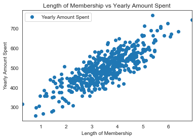

```python
num.plot(x='Length of Membership',y='Yearly Amount Spent',style='o')
plt.title('Length of Membership vs Yearly Amount Spent')
plt.xlabel('Length of Membership')
plt.ylabel('Yearly Amount Spent')
plt.show()
```

```python
num["Length of Membership"].corr(num['Yearly Amount Spent'])
```

```
0.8090835682475812
```

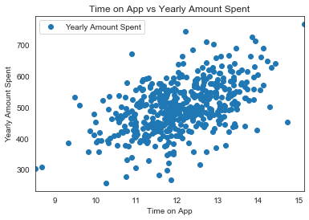

```python
num.plot(x='Time on App',y='Yearly Amount Spent',style='o')
plt.title('Time on App vs Yearly Amount Spent')
plt.xlabel('Time on App')
plt.ylabel('Yearly Amount Spent')
plt.show()
```

```python
num["Time on App"].corr(num['Yearly Amount Spent'])
```

```
0.4993277700534505
```

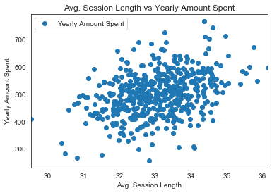

```python
num.plot(x='Avg. Session Length',y='Yearly Amount Spent',style='o')
plt.title('Avg. Session Length vs Yearly Amount Spent')
plt.xlabel('Avg. Session Length')
plt.ylabel('Yearly Amount Spent')
plt.show()
```

```python
num["Avg. Session Length"].corr(num['Yearly Amount Spent'])
```

```
0.35508829470764325
```

### Building model with only two features "Length of Membership" and "Time on App"based on colinearity score with target

```python
# Checking with two features
X2=num.drop(['Avg. Session Length', 'Time on Website','Yearly Amount Spent'], axis=1)
y2=num['Yearly Amount Spent']
X_train,X_test,y_train,y_test=train_test_split(X2,y2,test_size=0.3,random_state=0)
```

```python
lr1=LinearRegression()
lr1.fit(X_train,y_train)
```

```
LinearRegression(copy_X=True, fit_intercept=True, n_jobs=None, normalize=False)
```

```python
# r-squared for training and test datasets
print('Training data r-squared:', lr1.score(X_train, y_train))
print('Test data r-squared:', lr1.score(X_test, y_test))

print('Intercept', lr1.intercept_)
pd.DataFrame(data=lr1.coef_, index=X_train.columns,columns=['coef'])
```

```
Training data r-squared: 0.8927397308720332
Test data r-squared: 0.8519067019295846
Intercept -174.24160712701376
```

|  | coef |
| --- | --- |
| Time on App | 36.973598 |
| Length of Membership | 64.379970 |

```python
y_pred_1=lr1.predict(X_test)
```

```python
print('Mean Absolute Error:',mean_absolute_error(y_test, y_pred_1))
print('Mean Absolute percent error',np.mean(np.abs((y_test - y_pred_1) / y_test)) * 100)
print('Mean Squared Error:',mean_squared_error(y_test, y_pred_1))
print('Root Mean Squared Error:', np.sqrt(mean_squared_error(y_test, y_pred_1)))
print('R2 score:',r2_score(y_test, y_pred_1))
```

```
Mean Absolute Error: 24.53581034454643
Mean Absolute percent error 5.089726954198822
Mean Squared Error: 928.9918724747421
Root Mean Squared Error: 30.479367980237747
R2 score: 0.8519067019295847
```

### Conclusion:

#### 2. Comparing model with two feature with base model, has R-square score decrease from 98 to 85 and RMSE score increased from 9 to 30.

#### 3. Therefore model with 2 feature "Length of Membership" and "Time on App" dont stands out much when compared with model having 3 features "Length of Membership", "Time on App" and "Avg. Session Length".

#### 4. Risk- if dropping out any of this 3 features will impact overall score.

#### 5. Concluding feature "Length of Membership", "Time on App","Avg. Session Length" variables are affecting the target the most.

### Limitation:

#### Data size provided is small for 500 size, which can lead to higher R square score and resulting to underfitting problem. Underfitting problem can be overcome by adding me feature and appropriate data size. Adding feature like date and previous purchase history would be effective for analysis. Based on trend and seasonality for date can give insight for time spending pattern and yearly spending pattern by customers.